# Data visualization with seaborn part II - exercise solutions

```python
import warnings
warnings.filterwarnings('ignore')

import pandas as pd
import matplotlib.pyplot as plt
import seaborn as sns
%matplotlib inline
```

```python
plt.rcParams['figure.figsize']=8,8
```

### Exercise 1

We will work with the `titanic` dataset. The dataset is available through the seaborn package. You will have to run the following: `titanic = sns.load_dataset('titanic')`.

- Create a scatter plot that has a regression line of the `age` column on the `fare` one. Make an accompany plot of the residuals.
- Same plot as above but this time including separate regression lines for males and females. Try to change the colour palette using one of your choice.
- Create separate scatter plots for each class that include a regression line of the `age` column on the `fare`.
- Create a boxplot that shows the number the age range from each class.
- Same as above but including the sex information as well on the same plot. Try to create separate plots based on sex.
- Create a horizontal violinplot depicting the fare payed for each class. Include the survival status on the same plot.
- As above but create separate violin plots based on sex.

```python
titanic = sns.load_dataset('titanic')
titanic
```

|  | survived | pclass | sex | age | sibsp | parch | fare | embarked | class | who | adult_male | deck | embark_town | alive | alone |
| --- | --- | --- | --- | --- | --- | --- | --- | --- | --- | --- | --- | --- | --- | --- | --- |
| 0 | 0 | 3 | male | 22.0 | 1 | 0 | 7.2500 | S | Third | man | True | NaN | Southampton | no | False |
| 1 | 1 | 1 | female | 38.0 | 1 | 0 | 71.2833 | C | First | woman | False | C | Cherbourg | yes | False |
| 2 | 1 | 3 | female | 26.0 | 0 | 0 | 7.9250 | S | Third | woman | False | NaN | Southampton | yes | True |
| 3 | 1 | 1 | female | 35.0 | 1 | 0 | 53.1000 | S | First | woman | False | C | Southampton | yes | False |
| 4 | 0 | 3 | male | 35.0 | 0 | 0 | 8.0500 | S | Third | man | True | NaN | Southampton | no | True |
| ... | ... | ... | ... | ... | ... | ... | ... | ... | ... | ... | ... | ... | ... | ... | ... |
| 886 | 0 | 2 | male | 27.0 | 0 | 0 | 13.0000 | S | Second | man | True | NaN | Southampton | no | True |
| 887 | 1 | 1 | female | 19.0 | 0 | 0 | 30.0000 | S | First | woman | False | B | Southampton | yes | True |
| 888 | 0 | 3 | female | NaN | 1 | 2 | 23.4500 | S | Third | woman | False | NaN | Southampton | no | False |
| 889 | 1 | 1 | male | 26.0 | 0 | 0 | 30.0000 | C | First | man | True | C | Cherbourg | yes | True |
| 890 | 0 | 3 | male | 32.0 | 0 | 0 | 7.7500 | Q | Third | man | True | NaN | Queenstown | no | True |

891 rows × 15 columns

Create a scatter plot that has a regression line of the `age` column on the `fare` one. Make an accompany plot of the residuals.

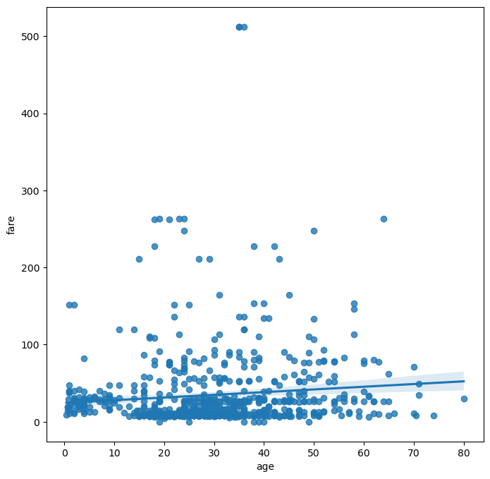

```python
sns.regplot(x='age', y='fare', data=titanic)
```

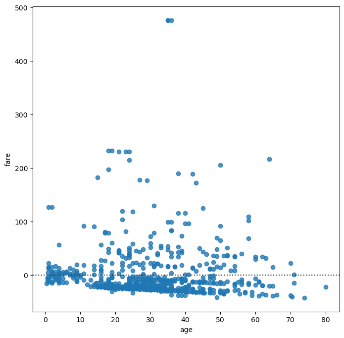

```python
sns.residplot(x='age', y='fare', data=titanic)
```

Same plot as above but this time including separate regression lines for males and females. Try to change the colour palette using one of your choice.

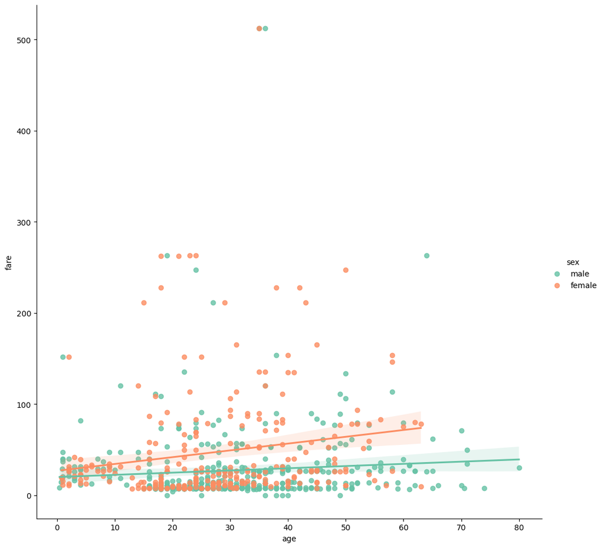

```python
sns.lmplot(x='age', y='fare',hue='sex',palette='Set2',height=10, data=titanic)
```

Create separate scatter plots for each class that include a regression line of the `age` column on the `fare`.

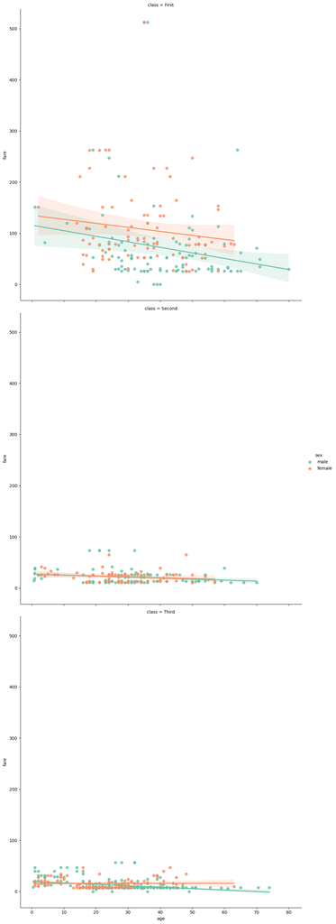

```python
sns.lmplot(x='age', y='fare',
           hue='sex',palette='Set2',
           row='class',height=10, data=titanic)
```

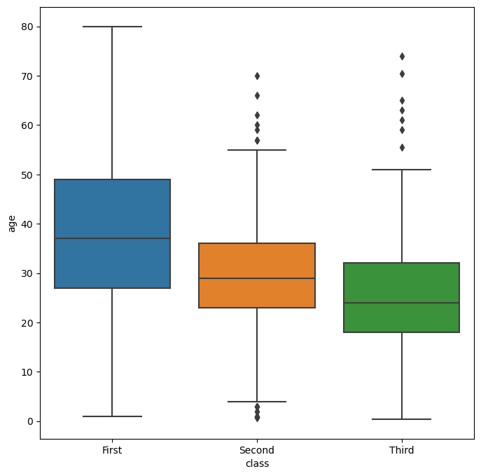

```python
sns.boxplot(x='class',y='age', data=titanic)
```

Same as above but including the sex information as well on the same plot. Try to create separate plots based on sex.

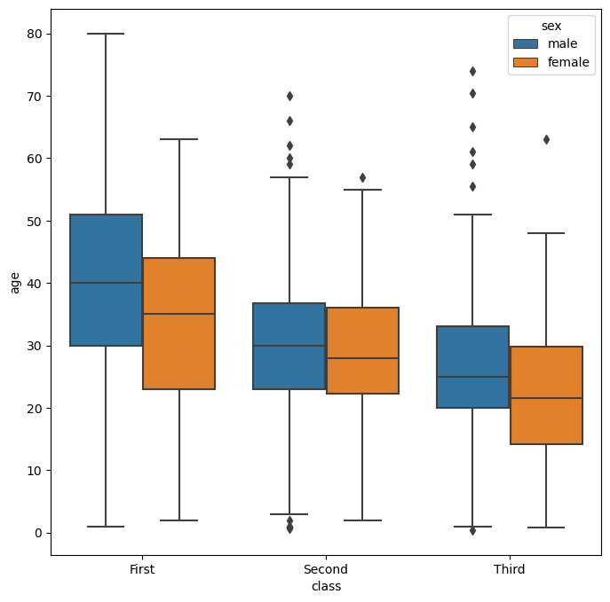

```python
sns.boxplot(x='class',y='age',hue='sex',data=titanic)
```

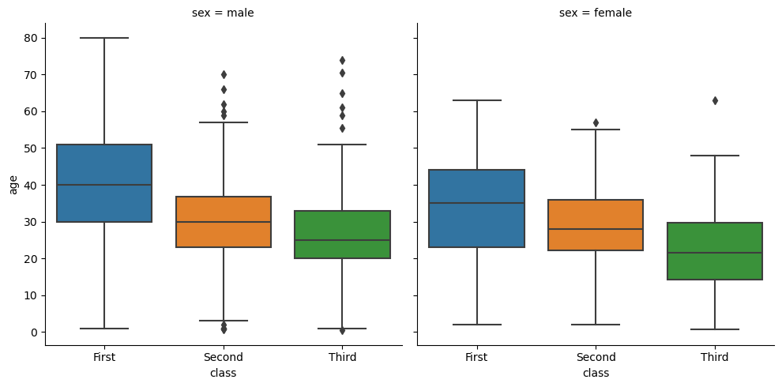

```python
sns.catplot(x='class', y='age', col='sex',kind='box', data=titanic)
```

Create a horizontal violinplot depicting the fare payed for each class. Include the survival status on the same plot.

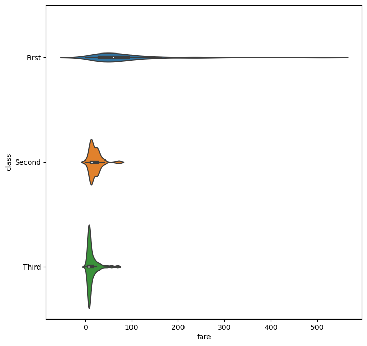

```python
sns.violinplot(x='fare',y='class', data=titanic)
```

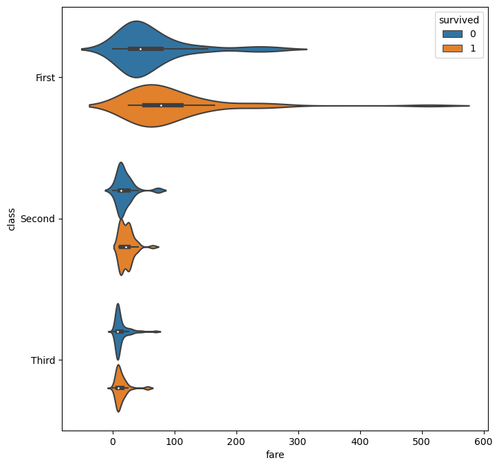

```python
sns.violinplot(x='fare', y='class', hue='survived', data=titanic)
```

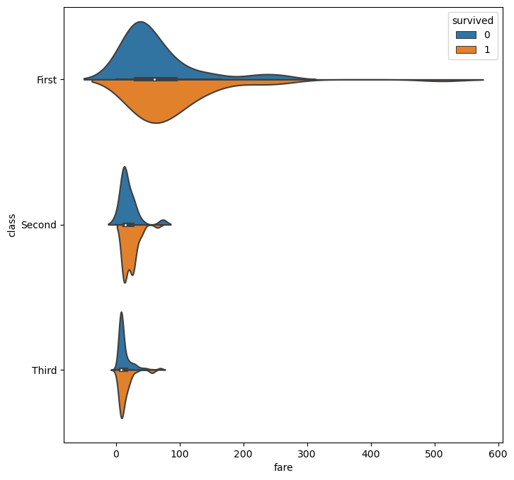

```python
sns.violinplot(x='fare', y='class', hue='survived',split=True, data=titanic)
```

As above but create separate violin plots based on sex.

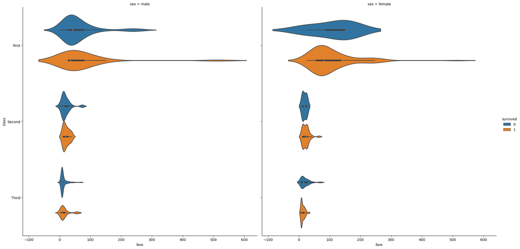

```python
sns.catplot(x='fare', y='class',
            hue='survived',col='sex',
            height=10,kind='violin',
            data=titanic)
```

### Exercise 2

We will work with the `tilapia_pheno.txt` file.

- Create a pair plot for all the growth related columns (Weight, Length and AGR).
- Same plot but using different colours for the two locations. Change the transparence of the points to 0.5.
- Calculate Pearson correlations amongst all the growth related columns (Weight, Length and AGR). Create a heatmap. Annotate the heatmap with the correlation values. Adjust the orientation of the y labels to facilitate the reader.

```python
til_pheno = pd.read_csv('tilapia_pheno.txt',sep="\t")
til_pheno.info()
```

```
<class 'pandas.core.frame.DataFrame'>
RangeIndex: 1752 entries, 0 to 1751
Data columns (total 12 columns):
 #   Column          Non-Null Count  Dtype
---  ------          --------------  -----
 0   PIT_TAG         1752 non-null   int64
 1   Location        1752 non-null   object
 2   Line            1752 non-null   object
 3   Family          1752 non-null   int64
 4   Age             1752 non-null   int64
 5   Pond            1752 non-null   int64
 6   Happa           1751 non-null   float64
 7   Weight_initial  1752 non-null   float64
 8   Weight_final    1752 non-null   float64
 9   Length_initial  1752 non-null   float64
 10  Length_final    1752 non-null   float64
 11  AGR             1752 non-null   float64
dtypes: float64(6), int64(4), object(2)
memory usage: 164.4+ KB
```

```python
til_pheno
```

|  | PIT_TAG | Location | Line | Family | Age | Pond | Happa | Weight_initial | Weight_final | Length_initial | Length_final | AGR |
| --- | --- | --- | --- | --- | --- | --- | --- | --- | --- | --- | --- | --- |
| 0 | 10977965 | Kunduchi | Wami | 1 | 154 | 2 | 3.0 | 84.30 | 201.50 | 14.2 | 18.0 | 0.761039 |
| 1 | 10978207 | Kunduchi | Wami | 1 | 154 | 1 | 2.0 | 67.80 | 0.00 | 13.4 | 0.0 | -0.440260 |
| 2 | 10978378 | Kunduchi | Wami | 1 | 154 | 2 | 4.0 | 103.94 | 225.90 | 14.4 | 18.5 | 0.791948 |
| 3 | 10978460 | Kunduchi | Wami | 1 | 154 | 1 | 1.0 | 84.85 | 239.20 | 14.5 | 19.9 | 1.002273 |
| 4 | 10977732 | Kunduchi | Wami | 1 | 154 | 1 | 1.0 | 78.29 | 195.60 | 14.0 | 19.0 | 0.761753 |
| ... | ... | ... | ... | ... | ... | ... | ... | ... | ... | ... | ... | ... |
| 1747 | 10978369 | Pangani | Ruaha | 35 | 133 | 1 | 1.0 | 26.93 | 86.12 | 9.4 | 13.8 | 0.445038 |
| 1748 | 10978013 | Pangani | Ruaha | 35 | 133 | 2 | 3.0 | 18.02 | 0.00 | 8.6 | 0.0 | -0.135489 |
| 1749 | 10978579 | Pangani | Ruaha | 35 | 133 | 2 | 3.0 | 46.97 | 101.54 | 11.0 | 14.0 | 0.410301 |
| 1750 | 10977708 | Pangani | Ruaha | 35 | 133 | 1 | 1.0 | 39.83 | 64.24 | 10.7 | 13.4 | 0.183534 |
| 1751 | 10977975 | Pangani | Ruaha | 35 | 133 | 1 | 2.0 | 32.14 | 57.24 | 10.0 | 12.0 | 0.188722 |

1752 rows × 12 columns

Create a pair plot for all the growth related columns (Weight, Length and AGR).

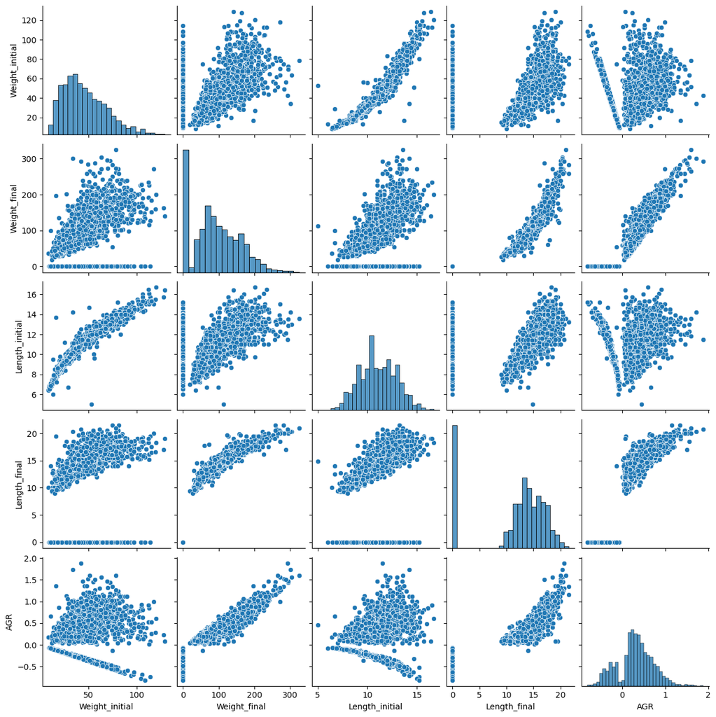

```python
sns.pairplot(til_pheno[['Weight_initial','Weight_final','Length_initial','Length_final','AGR']] )
```

Same plot but using different colours for the two locations. Change the transparence of the points to 0.5.

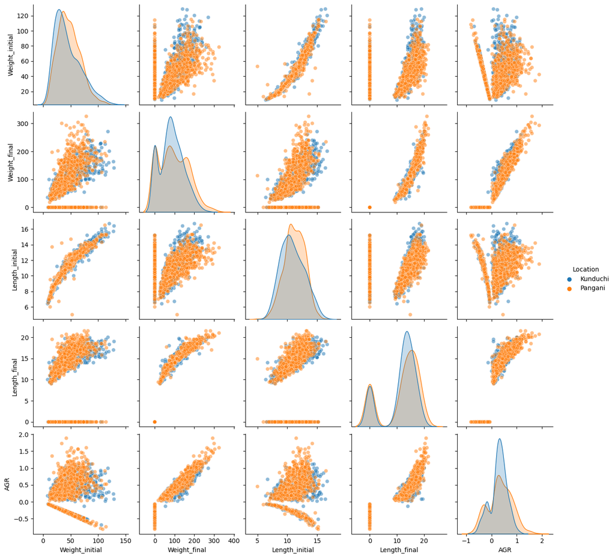

```python
sns.pairplot(til_pheno[['Weight_initial','Weight_final','Length_initial','Length_final','AGR','Location']],
             hue='Location', plot_kws={'alpha':0.5})
```

Calculate Pearson correlations amongst all the growth related columns (Weight, Length and AGR). Create a heatmap. Annotate the heatmap with the correlation values. Adjust the orientation of the y labels to facilitate the reader.

```python
growth_corr = til_pheno[['Weight_initial','Weight_final','Length_initial','Length_final','AGR']].corr()
growth_corr
```

|  | Weight_initial | Weight_final | Length_initial | Length_final | AGR |
| --- | --- | --- | --- | --- | --- |
| Weight_initial | 1.000000 | 0.514052 | 0.957177 | 0.312355 | 0.206292 |
| Weight_final | 0.514052 | 1.000000 | 0.523587 | 0.886276 | 0.942152 |
| Length_initial | 0.957177 | 0.523587 | 1.000000 | 0.329928 | 0.232442 |
| Length_final | 0.312355 | 0.886276 | 0.329928 | 1.000000 | 0.893434 |
| AGR | 0.206292 | 0.942152 | 0.232442 | 0.893434 | 1.000000 |

```
(array([0.5, 1.5, 2.5, 3.5, 4.5]),
 [Text(0, 0.5, 'Weight_initial'),
```

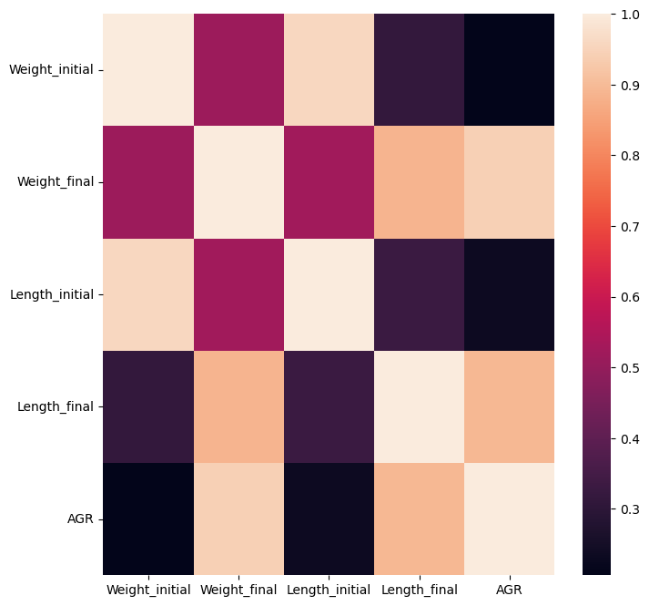

```python
sns.heatmap(growth_corr, annot=False)
plt.yticks(rotation=0)
```

```
(array([0.5, 1.5, 2.5, 3.5, 4.5]),
 [Text(0, 0.5, 'Weight_initial'),
```

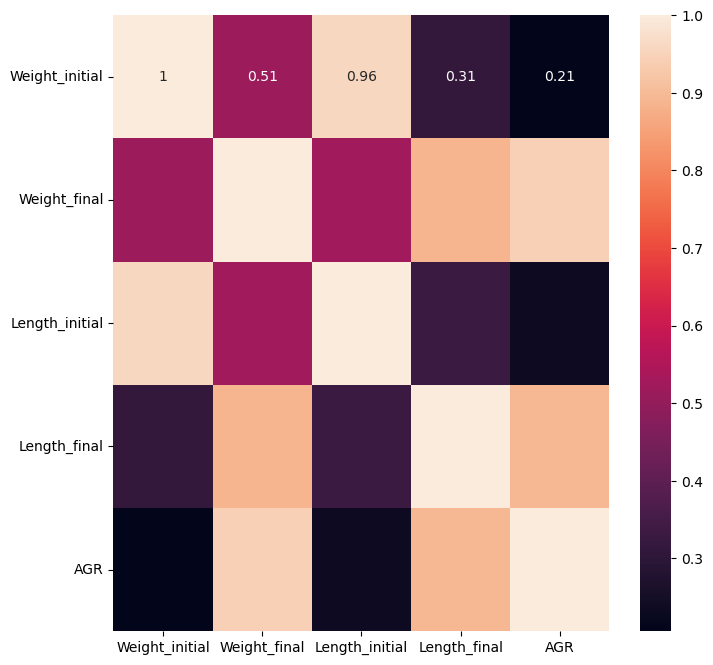

```python
sns.heatmap(growth_corr, annot=True)
plt.yticks(rotation=0)
```

### Exercise 3

- Create a violin plot depicting the auc score of each model.
- Same as above but this time on a horizontal violin plot depict separate auc scores for skewed and not skewed cases of each model. Add a legend.

```python
auc_score = pd.read_csv('auc_scores.csv')
auc_score
```

|  | GBLUP | Adaboost | DT | SVM | RF | XGB | Skewed |
| --- | --- | --- | --- | --- | --- | --- | --- |
| 0 | 0.76 | 0.73 | 0.54 | 0.79 | 0.79 | 0.81 | No |
| 1 | 0.74 | 0.74 | 0.55 | 0.78 | 0.76 | 0.79 | No |
| 2 | 0.81 | 0.80 | 0.55 | 0.84 | 0.83 | 0.85 | No |
| 3 | 0.79 | 0.78 | 0.55 | 0.83 | 0.81 | 0.83 | No |
| 4 | 0.81 | 0.79 | 0.56 | 0.82 | 0.81 | 0.82 | No |
| 5 | 0.83 | 0.77 | 0.54 | 0.84 | 0.83 | 0.83 | No |
| 6 | 0.78 | 0.75 | 0.56 | 0.84 | 0.81 | 0.82 | No |
| 7 | 0.79 | 0.76 | 0.54 | 0.81 | 0.79 | 0.81 | No |
| 8 | 0.81 | 0.77 | 0.56 | 0.86 | 0.84 | 0.84 | No |
| 9 | 0.77 | 0.77 | 0.54 | 0.81 | 0.79 | 0.82 | No |
| 10 | 0.80 | 0.76 | 0.53 | 0.81 | 0.82 | 0.82 | Yes |
| 11 | 0.76 | 0.72 | 0.54 | 0.78 | 0.76 | 0.79 | Yes |
| 12 | 0.79 | 0.73 | 0.54 | 0.82 | 0.80 | 0.82 | Yes |
| 13 | 0.82 | 0.77 | 0.55 | 0.84 | 0.83 | 0.83 | Yes |
| 14 | 0.81 | 0.78 | 0.53 | 0.83 | 0.82 | 0.83 | Yes |
| 15 | 0.80 | 0.78 | 0.54 | 0.81 | 0.81 | 0.83 | Yes |
| 16 | 0.83 | 0.78 | 0.53 | 0.84 | 0.84 | 0.86 | Yes |
| 17 | 0.83 | 0.78 | 0.53 | 0.85 | 0.84 | 0.85 | Yes |
| 18 | 0.84 | 0.80 | 0.55 | 0.84 | 0.85 | 0.85 | Yes |
| 19 | 0.79 | 0.77 | 0.54 | 0.82 | 0.79 | 0.82 | Yes |

```python
auc_score=pd.melt(auc_score,id_vars="Skewed",
                  value_vars=["GBLUP","Adaboost","DT","SVM","RF","XGB"])
auc_score.columns=["Skewed","Model","AUC"]
auc_score
```

|  | Skewed | Model | AUC |
| --- | --- | --- | --- |
| 0 | No | GBLUP | 0.76 |
| 1 | No | GBLUP | 0.74 |
| 2 | No | GBLUP | 0.81 |
| 3 | No | GBLUP | 0.79 |
| 4 | No | GBLUP | 0.81 |
| ... | ... | ... | ... |
| 115 | Yes | XGB | 0.83 |
| 116 | Yes | XGB | 0.86 |
| 117 | Yes | XGB | 0.85 |
| 118 | Yes | XGB | 0.85 |
| 119 | Yes | XGB | 0.82 |

120 rows × 3 columns

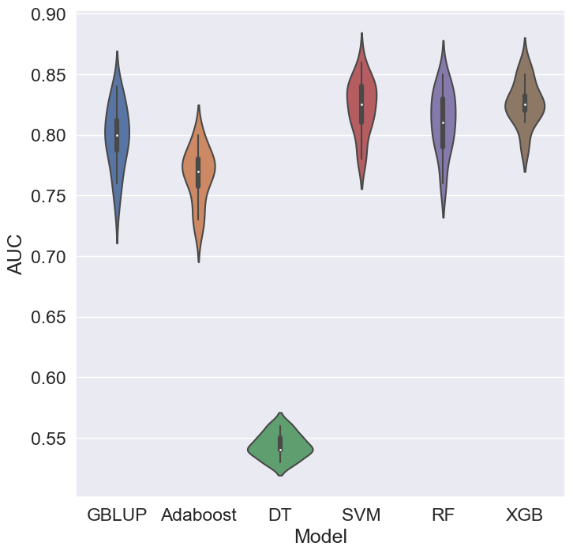

```python
sns.set(font_scale=1.5)
sns.violinplot(data=auc_score, x="Model",y="AUC")
```

[figure not shown]

```python
sns.set(font_scale=1.5)
sns.violinplot(data=auc_score, x="AUC",y="Model",
                   hue="Skewed",split=True,legend=False)
plt.legend(loc='upper left',title="Balanced ratio")
```